# Import

```python
import os
os.environ["TF_CPP_MIN_LOG_LEVEL"] = "3"
import matplotlib.pyplot as plt
import numpy as np
import tensorflow as tf
from PIL import Image
from tensorflow.keras.layers import Input, Dense, Conv2D, Activation, MaxPool2D
from tensorflow.keras.layers import BatchNormalization, Flatten, Reshape, Conv2DTranspose, LeakyReLU
from tensorflow.keras.models import Model
from tensorflow.keras.optimizers import Adam, SGD
from keras.preprocessing.image import ImageDataGenerator
print("")
from tqdm import trange, tqdm
from tensorflow.keras.utils import Sequence
import pydot

import graphviz
## Seeding
np.random.seed(42)
tf.random.set_seed(42)
```

```python
print("Num GPUs Available: ", len(tf.config.experimental.list_physical_devices('GPU')))
```

```
Num GPUs Available:  1
```

# Data generator

On prépare notre jeu de train et de test qui vont servir à entraîner notre modèle. Ici le jeu de test servira aussi de jeu de validation. On dispose d'un dataset de 70 000 images. Nos ordinateurs ne disposent pas de la capacité en RAM pour charger toutes ce simages directement. On utilise donc la fonction flow_from_directory du package keras.preprocessing.image.ImageDataGenerator qui va permettre de charger en temps réel, au cours de l'entrainement, les images du jeu de données. Ainsi notre RAM ne sera pas saturée et on pourra faire tourner notre algorithme sur la totalité de notre dataset et avoir de meilleurs résultats. On utilise le class_mode input car notre validation se fait sur l'image elle-même et un batch_size de 64 (avec plus le code a du mal a tourner). On conserve nos images en 128 afin d'avoir une meilleure résolution. Nos images sont en RGB. On ne fait pas de transformation particulière sur nos données.

```python
##Train

train_datagen = ImageDataGenerator(rescale = 1 / 255.0,)

train_generator = train_datagen.flow_from_directory(
    directory = "dataset//train//",
    target_size = (128, 128),
    color_mode = "rgb",
    batch_size = 64,
    class_mode = "input",
    shuffle = False,
    seed = 42
)

## Test

test_datagen = ImageDataGenerator(rescale = 1 / 255.0)

test_generator = test_datagen.flow_from_directory(
    directory = "dataset//test//",
    target_size = (128, 128),
    color_mode = "rgb",
    batch_size = 64,
    class_mode = "input",
    shuffle = False,
    seed = 42
)
```

```
Found 56000 images belonging to 1 classes.
Found 14000 images belonging to 1 classes.
```

# Architecture du réseau de neurones

```python
class Autoencoder(Model):
    def __init__(self, latent_dim, H,W,C):
        super(Autoencoder, self).__init__()
        self.latent_dim = latent_dim
        self.encoder = tf.keras.Sequential([
            Input(shape = (H, W, C), name = "inputs"),
            Conv2D(64, (3, 3), padding = "same"),
            BatchNormalization(),
            LeakyReLU(alpha = 0.2),
            MaxPool2D((2, 2)),
            Conv2D(128, (3, 3), padding = "same"),
            BatchNormalization(),
            LeakyReLU(alpha = 0.2),
            MaxPool2D((2, 2)),
            Conv2D(256, (3, 3), padding = "same"),
            BatchNormalization(),
            LeakyReLU(alpha = 0.2),
            MaxPool2D((2, 2)),
            Flatten(),
            Dense(latent_dim, name = "latent"),
        ])
        self.decoder = tf.keras.Sequential([
            Dense(65536),
            LeakyReLU(alpha = 0.2),
            Reshape((16, 16, 256)),
            Conv2DTranspose(128, (3, 3), strides = 2, padding="same"),
            BatchNormalization(),
            LeakyReLU(alpha = 0.2),
            Conv2DTranspose(256, (3, 3), strides = 2, padding="same"),
            BatchNormalization(),
            LeakyReLU(alpha = 0.2),
            Conv2DTranspose(3, (3, 3), strides = 2, padding="same"),
            BatchNormalization(),
            Activation("sigmoid", name = "outputs")
        ])

    def call(self, x):
        encoded = self.encoder(x)
        decoded = self.decoder(encoded)
        return decoded

## Hyperparameters
H = 128
W = 128
C = 3
latent_dim = 128

## Compilation
autoencoder = Autoencoder(latent_dim, H, W ,C)
autoencoder.compile(optimizer = Adam(1e-3), loss = 'binary_crossentropy')
autoencoder.build((None, 128, 128, 3))
autoencoder.summary()

## Entrainement
autoencoder.fit(
    train_generator,
    epochs = 15,
    batch_size = 64,
    shuffle = False,
    validation_data = test_generator
)

## Prediction sur le jeu de test
test_pred_y = autoencoder.predict(test_generator)
```

```
Metal device set to: Apple M1
Model: "autoencoder"
_________________________________________________________________
 Layer (type)                Output Shape              Param #
=================================================================
 sequential (Sequential)     (None, 128)               8761344

 sequential_1 (Sequential)   (None, 128, 128, 3)       9052815

=================================================================
Total params: 17,814,159
Trainable params: 17,812,489
Non-trainable params: 1,670
_________________________________________________________________
```

Les fonctions pour print l'history de notre AE ne fonctionnent pas donc on le fait à la main :

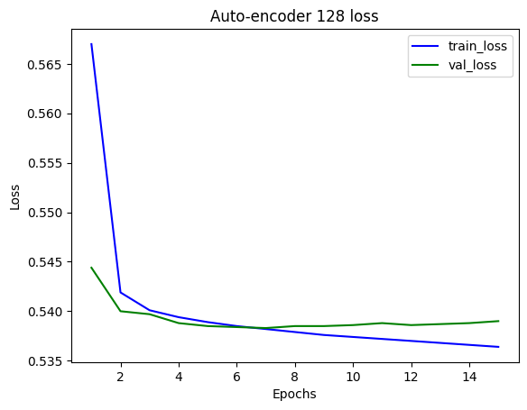

```python
loss = [0.5670,0.5419,0.5401,0.5394,0.5389,0.5385,0.5382,0.5379,0.5376,0.5374,0.5372,0.5370,0.5368,0.5366, 0.5364 ]
val_loss = [0.5444,0.5400,0.5397,0.5388,0.5385,0.5384,0.5383,0.5385,0.5385,0.5386,0.5388,0.5386,0.5387,0.5388 , 0.5390]
epoch = [i for i in range(1,16)]
plt.plot(epoch,loss,label = 'train_loss', color = 'blue')
plt.plot(epoch,val_loss,label = 'val_loss', color = 'green')
plt.title("Auto-encoder 128 loss")
plt.xlabel("Epochs")
plt.ylabel("Loss")
plt.legend()
plt.show()
```

On overfitt assez rapidement. Il faudrait peut être plus de données ou alors réaliser une segmentation sur les images pour enlever le bruit du bg.

None correspond à la dimension de la batch_size : on a ici entrainer en prenant batch_size = 64 pour obtenir de meilleurs résultats sans dépasser la limite de calculation de notre GPU.

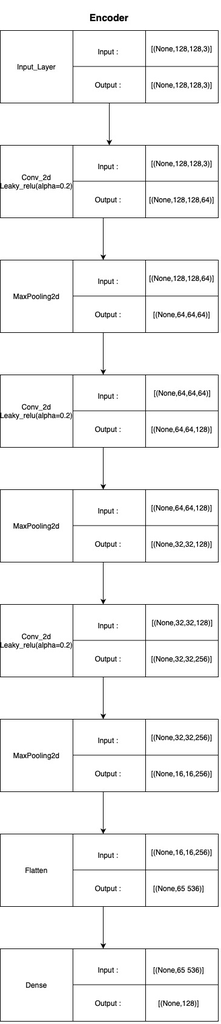

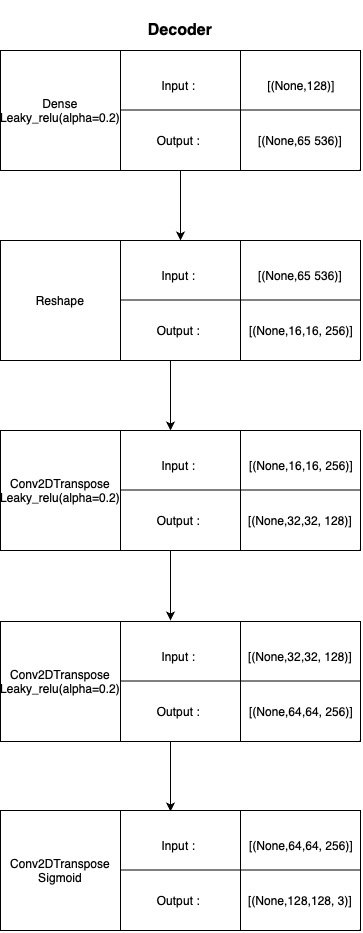

# Sauvergarde des modèles

```python
autoencoder.encoder.save("saved_model/encoder_128_v2.tf")
autoencoder.decoder.save("saved_model/decoder_128_v2.tf")
```

[output not shown]

[output not shown]

```
INFO:tensorflow:Assets written to: saved_model/encoder_128_v2.tf/assets
```

```
INFO:tensorflow:Assets written to: saved_model/encoder_128_v2.tf/assets
```

[output not shown]

[output not shown]

```
INFO:tensorflow:Assets written to: saved_model/decoder_128_v2.tf/assets
```

```
INFO:tensorflow:Assets written to: saved_model/decoder_128_v2.tf/assets
```

# Chargement des modèles

Pendant l'entrainement on avait compilé directement l'autoencoder donc on doit recompiler ici séparèment l'encoder et le decoder (car on a besoin qu'il soit séparé pour y intégrer l'algorithme génetique).

```python
encoder = tf.keras.models.load_model("saved_model/encoder_128_v2.tf",compile=False)
decoder = tf.keras.models.load_model("saved_model/decoder_128_v2.tf",compile=False)

encoder.compile(optimizer=Adam(1e-3), loss='binary_crossentropy')
decoder.compile(optimizer=Adam(1e-3), loss='binary_crossentropy')
```

```
Metal device set to: Apple M1
```

# Affichage des images prédites

```python
# Création d'un dataset test pour pouvoir afficher aussi les images originales (pas possible avec le test generator)
X = []
for direct in tqdm(os.listdir("dataset/test/")):
    if direct != ".DS_Store":
        for file in os.listdir(f"dataset/test/{direct}/"):
            if file != ".DS_Store" :
                img = Image.open(f"dataset/test/{direct}/{file}")
                arr = np.array(img)/255
            X.append(arr)
X = np.array(X)
```

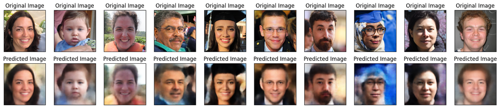

```python
test_pred_y = encoder.predict(X)
test_pred = decoder.predict(test_pred_y)

H = 128
W = 128
C = 3

n = 10  ## how many digits we will display
plt.figure(figsize=(20, 4))

for i in range(n):
    ## display original
    ax = plt.subplot(2, n, i + 1)
    ax.set_title("Original Image")
    plt.imshow(X[i].reshape(H, W, C))
    plt.gray()
    ax.get_xaxis().set_visible(False)
    ax.get_yaxis().set_visible(False)

    ## display reconstruction
    ax = plt.subplot(2, n, i + 1 + n)
    ax.set_title("Predicted Image")
    plt.imshow(test_pred[i].reshape(H, W, C))
    plt.gray()
    ax.get_xaxis().set_visible(False)
    ax.get_yaxis().set_visible(False)
plt.show()
```

## Premier test avec segmentation

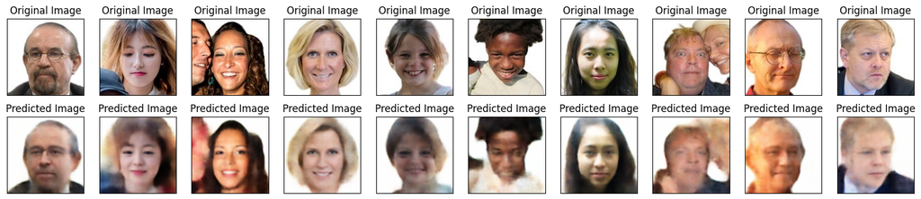

```python
test_pred_y = encoder.predict(X)
test_pred = decoder.predict(test_pred_y)

n = 10  ## how many digits we will display
plt.figure(figsize=(20, 4))

for i in range(n):
    ## display original
    ax = plt.subplot(2, n, i + 1)
    ax.set_title("Original Image")
    plt.imshow(X[i].reshape(H, W, C))
    plt.gray()
    ax.get_xaxis().set_visible(False)
    ax.get_yaxis().set_visible(False)

    ## display reconstruction
    ax = plt.subplot(2, n, i + 1 + n)
    ax.set_title("Predicted Image")
    plt.imshow(test_pred[i].reshape(H, W, C))
    plt.gray()
    ax.get_xaxis().set_visible(False)
    ax.get_yaxis().set_visible(False)
plt.show()
```

On a utilisé un software pour génerer quelques images segmentées. On pense qu'une prochaine piste serait de développer un algo de segmentation pour l'appliquer à tout notre jeu de données, l'entrainer dessus afin d'avoir de meilleurs résultats.